# Data Visualization Class Work

Spring 2020

Martha Eichlersmith

These are the projects and labs completed for Data Visualization (STAT 302) - Spring 2020.

# Lab 01

## Overview

The goals of this lab are to (1) ensure that the major software for this course is properly installed and functional, (2) develop and follow a proper workflow, and (3) work together to construct a few plots to explore a dataset using `ggplot2` — demonstration of the utility and power of `ggplot2`.

**Don’t worry if you cannot do everything here by yourself.** You are just getting started and the learning curve is steep, but remember that the instructional team and your classmates will be there to provide support. Persevere and put forth an honest effort and this course will payoff.

**Load Packages** `tidyverse`, `ggstance`, `skimr`

```r
# Load package(s)
suppressPackageStartupMessages(library(tidyverse))
suppressPackageStartupMessages(library(ggstance))
suppressPackageStartupMessages(library(skimr))
```

## Dataset

We’ll be using data from the [**lego** package](https://github.com/seankross/lego) which is already in the `/data` subdirectory, along with many other processed datasets, as part of the zipped folder for this lab.

## Exercise 1

Let’s look at some interesting patterns in the history of LEGO! We’ll be using data from the [**lego** package](https://github.com/seankross/lego) located `data/legosets.rda`. We will work through this exercise together in class.

```r
load(file = "data/legosets.rda")
```

### 1a Inspect the data

The **lego** package provides a helpful dataset some interesting variables. Let’s take a quick look at the data.

```r
#print the top of the data sets
#head(legosets)

#focus of the variables
glimpse(legosets)
```

```
## Observations: 6,172
## Variables: 14
## $ Item_Number  <chr> "10246", "10247", "10248", "10249", "10581", "10582", ...
## $ Name         <chr> "Detective's Office", "Ferris Wheel", "Ferrari F40", "...
## $ Year         <int> 2015, 2015, 2015, 2015, 2015, 2015, 2015, 2015, 2015, ...
## $ Theme        <chr> "Advanced Models", "Advanced Models", "Advanced Models...
## $ Subtheme     <chr> "Modular Buildings", "Fairground", "Vehicles", "Winter...
## $ Pieces       <int> 2262, 2464, 1158, 898, 13, 39, 32, 105, 13, 11, 52, 13...
## $ Minifigures  <int> 6, 10, NA, NA, 1, 2, 2, 3, 2, 2, 3, 1, NA, NA, NA, NA,...
## $ Image_URL    <chr> "http://images.brickset.com/sets/images/10246-1.jpg", ...
## $ GBP_MSRP     <dbl> 132.99, 149.99, 69.99, 59.99, 9.99, 16.99, 19.99, 49.9...
## $ USD_MSRP     <dbl> 159.99, 199.99, 99.99, 79.99, 9.99, 19.99, 24.99, 59.9...
## $ CAD_MSRP     <dbl> 199.99, 229.99, 119.99, NA, 12.99, 24.99, 29.99, 69.99...
## $ EUR_MSRP     <dbl> 149.99, 179.99, 89.99, 69.99, 9.99, 19.99, 24.99, 59.9...
## $ Packaging    <chr> "Box", "Box", "Box", "Box", "Box", "Box", "Box", "Box"...
## $ Availability <chr> "Retail - limited", "Retail - limited", "LEGO exclusiv...
```

```r
#short eda
skim_without_charts(legosets)
```

Data summary

| Name | legosets |
| --- | --- |
| Number of rows | 6172 |
| Number of columns | 14 |
| _______________________ |  |
| Column type frequency: |  |
| character | 7 |
| numeric | 7 |
| ________________________ |  |
| Group variables | None |

**Variable type: character**

| skim_variable | n_missing | complete_rate | min | max | empty | n_unique | whitespace |
| --- | --- | --- | --- | --- | --- | --- | --- |
| Item_Number | 0 | 1 | 1 | 13 | 0 | 5854 | 0 |
| Name | 0 | 1 | 2 | 73 | 0 | 5519 | 4 |
| Theme | 0 | 1 | 4 | 28 | 0 | 115 | 0 |
| Subtheme | 0 | 1 | 0 | 32 | 2206 | 358 | 1 |
| Image_URL | 0 | 1 | 46 | 58 | 0 | 6172 | 0 |
| Packaging | 0 | 1 | 3 | 21 | 0 | 14 | 0 |
| Availability | 0 | 1 | 6 | 21 | 0 | 8 | 0 |

**Variable type: numeric**

| skim_variable | n_missing | complete_rate | mean | sd | p0 | p25 | p50 | p75 | p100 |
| --- | --- | --- | --- | --- | --- | --- | --- | --- | --- |
| Year | 0 | 1.00 | 2004.71 | 8.91 | 1971.00 | 2000.00 | 2006.00 | 2012.00 | 2015.00 |
| Pieces | 112 | 0.98 | 215.17 | 356.20 | 0.00 | 30.00 | 82.00 | 256.25 | 5922.00 |
| Minifigures | 2672 | 0.57 | 2.85 | 2.72 | 1.00 | 1.00 | 2.00 | 4.00 | 32.00 |
| GBP_MSRP | 1980 | 0.68 | 23.45 | 31.93 | 0.00 | 5.99 | 12.99 | 29.99 | 509.99 |
| USD_MSRP | 355 | 0.94 | 27.90 | 39.32 | 0.00 | 6.00 | 14.99 | 34.99 | 789.99 |
| CAD_MSRP | 4190 | 0.32 | 46.34 | 58.46 | 2.99 | 12.99 | 24.99 | 54.99 | 789.99 |
| EUR_MSRP | 4399 | 0.29 | 35.98 | 46.61 | 0.00 | 9.99 | 19.99 | 39.99 | 699.99 |

Notice there are a lot of missing variables, especially when it comes to pricing - this will be important for when we calculate the means.

### 1b Price per year

First, let’s look at the average cost of LEGO sets over time. The main variable of interest here is `USD_MSRP`, or the manufacturer’s suggested retail price in constant dollars (i.e. not adjusted for inflation).

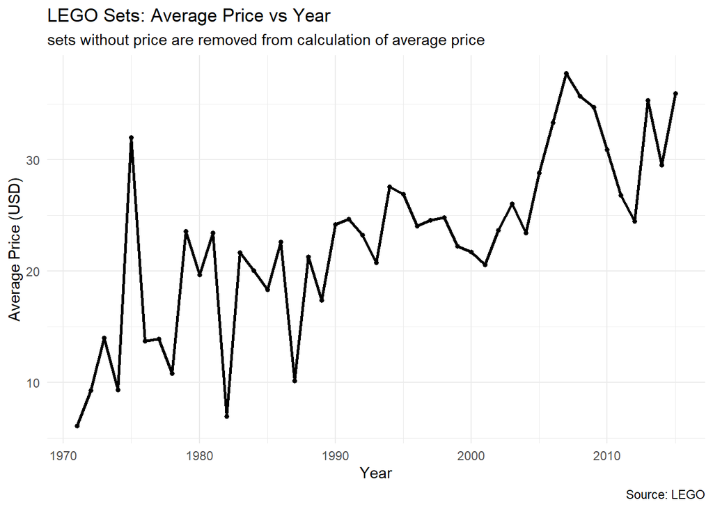

```r
#`drop` NA's at top
df.1b <- legosets %>%
  drop_na(USD_MSRP) %>%
  group_by(Year) %>%
  summarize(
    AveragePrice = mean(USD_MSRP)
  )

#`remove` NA's in mean function
#equivalent to `drop` NAs at top for this task
#df.1b <- legosets %>%
#  group_by(Year) %>%
#  summarize(
#    AverageCost = mean(USD_MSRP, na.rm=TRUE)
#    )

ggplot(df.1b, aes(Year, AveragePrice))+
  geom_point(size=1.25)+
  geom_line(size=1)+
  ggtitle("LEGO Sets: Average Price vs Year")+
  theme_minimal()+
  labs( #lables on the plot
     x = "Year"
   , y = "Average Price (USD)"
   , subtitle = "sets without price are removed from calculation of average price"
   , caption = "Source: LEGO"
    )
```

Is the increase in price simply due to inflation? Could get data from federal resersve and plot inflation-adjusted price vs year.

### 1c Pieces per year

Next, let’s look at how the number of pieces per set has changed over time. Because Duplo sets are much smaller (since they’re designed for toddlers), we’ll make a special indicator variable for them.

#### All Years

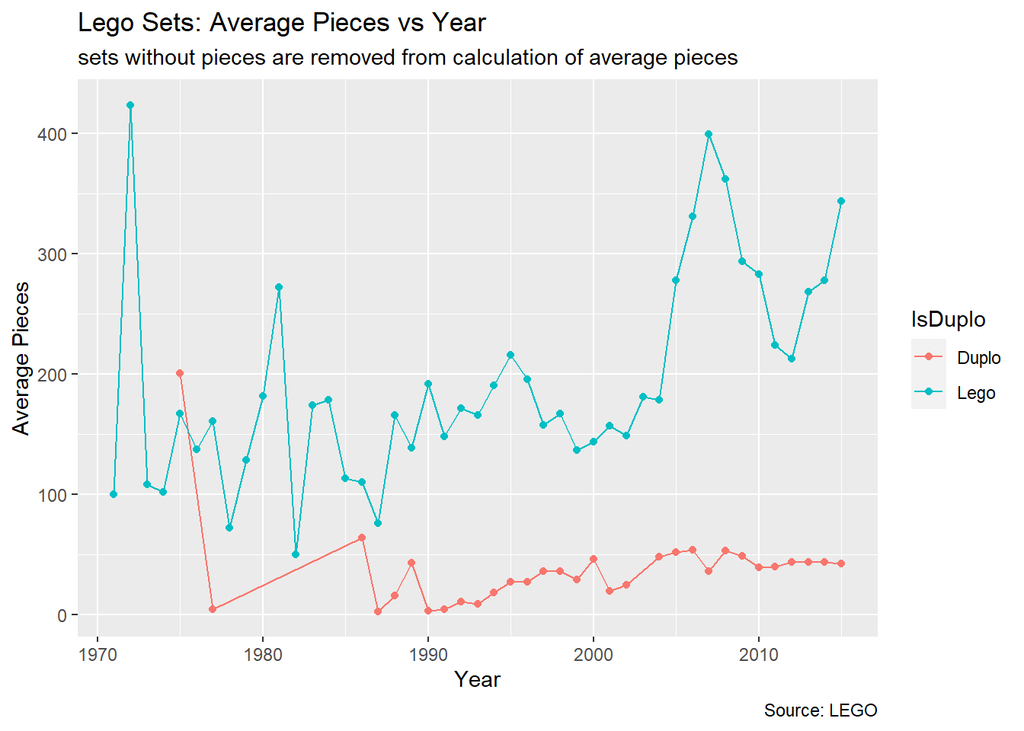

```r
df.1c <- legosets %>%
  mutate(IsDuplo = ifelse(Theme == "Duplo", "Duplo", "Lego")) %>%
  drop_na(Pieces) %>%
  group_by(Year, IsDuplo) %>%
  summarize(
     AveragePieces = mean(Pieces)
    ,num_sets = n()
    )

#same plot
ggplot(df.1c, aes(Year, AveragePieces, color=IsDuplo))+
  geom_point()+
  geom_line()+
  ggtitle("Lego Sets: Average Pieces vs Year")+
  labs( #lables on the plot
     x = "Year"
   , y = "Average Pieces"
   , subtitle = "sets without pieces are removed from calculation of average pieces"
   , caption = "Source: LEGO"
    )
```

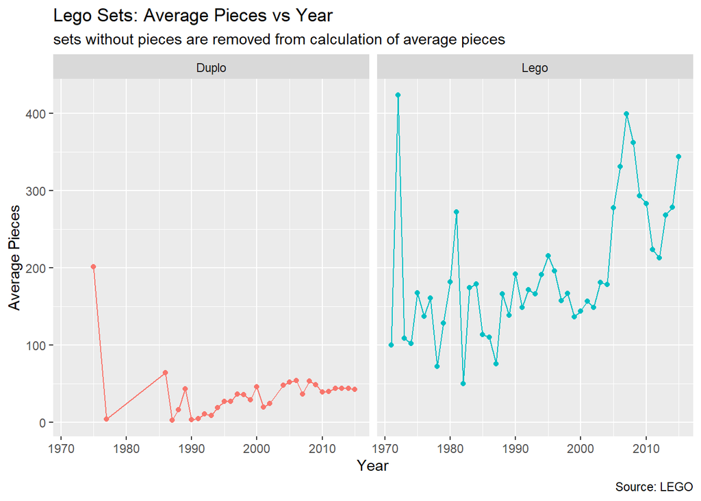

```r
#facet plots
ggplot(df.1c, aes(Year, AveragePieces, color=IsDuplo))+
  facet_wrap(~IsDuplo, ncol=2, scales="fixed")+
  geom_point()+
  geom_line()+
  ggtitle("Lego Sets: Average Pieces vs Year")+
  labs( #lables on the plot
     x = "Year"
   , y = "Average Pieces"
   , subtitle = "sets without pieces are removed from calculation of average pieces"
   , caption = "Source: LEGO"
    )+
  theme(
    legend.position = "none"
  )
```

#### Data after 1985

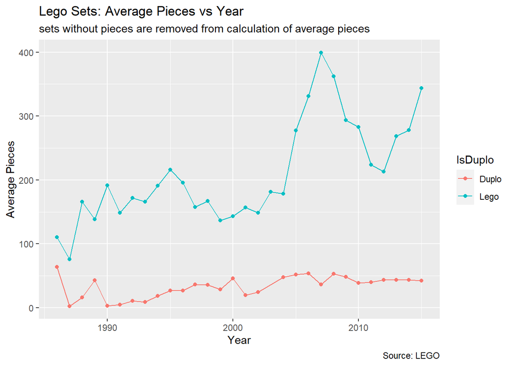

```r
df.1c <- legosets %>%
  mutate(IsDuplo = ifelse(Theme == "Duplo", "Duplo", "Lego")) %>%
  drop_na(Pieces) %>%
  filter(Year > 1985) %>%
  group_by(Year, IsDuplo) %>%
  summarize(
     AveragePieces = mean(Pieces)
    ,num_sets = n()
    )

#same plot
ggplot(df.1c, aes(Year, AveragePieces, color=IsDuplo))+
  geom_point()+
  geom_line()+
  ggtitle("Lego Sets: Average Pieces vs Year")+
  labs( #lables on the plot
     x = "Year"
   , y = "Average Pieces"
   , subtitle = "sets without pieces are removed from calculation of average pieces"
   , caption = "Source: LEGO"
    )
```

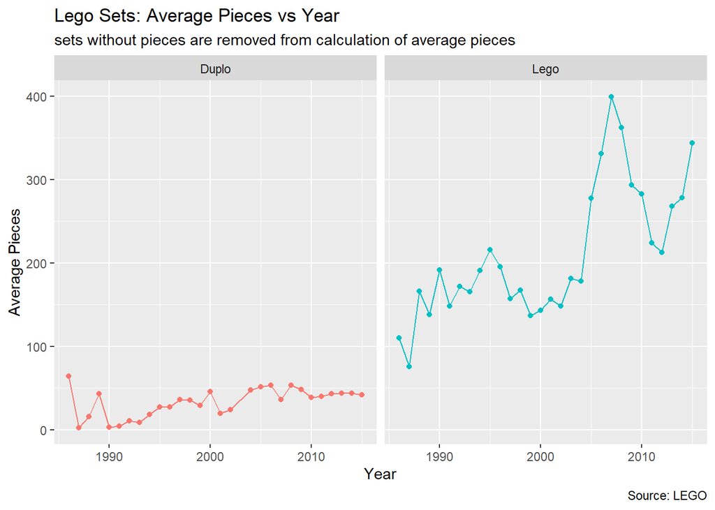

```r
#facet plots
ggplot(df.1c, aes(Year, AveragePieces, color=IsDuplo))+
  facet_wrap(~IsDuplo, ncol=2, scales="fixed")+
  geom_point()+
  geom_line()+
  ggtitle("Lego Sets: Average Pieces vs Year")+
  labs( #lables on the plot
     x = "Year"
   , y = "Average Pieces"
   , subtitle = "sets without pieces are removed from calculation of average pieces"
   , caption = "Source: LEGO"
    )+
  theme(
    legend.position = "none"
  )
```

### 1d LEGO set themes

In the 1990s, [LEGO began partnering with famous brands and franchises](https://www.cnbc.com/2018/04/27/lego-marketing-strategy-made-it-world-favorite-toy-brand.html) to boost its own sales. First, let’s see how many different “themes” LEGO now offers:

```r
length(unique(legosets$Theme))
```

```
## [1] 115
```

```r
legosets %>%
  distinct(Theme) %>%
  summarize ( n_themes = n())
```

```
## # A tibble: 1 x 1
##   n_themes
##      <int>
## 1      115
```

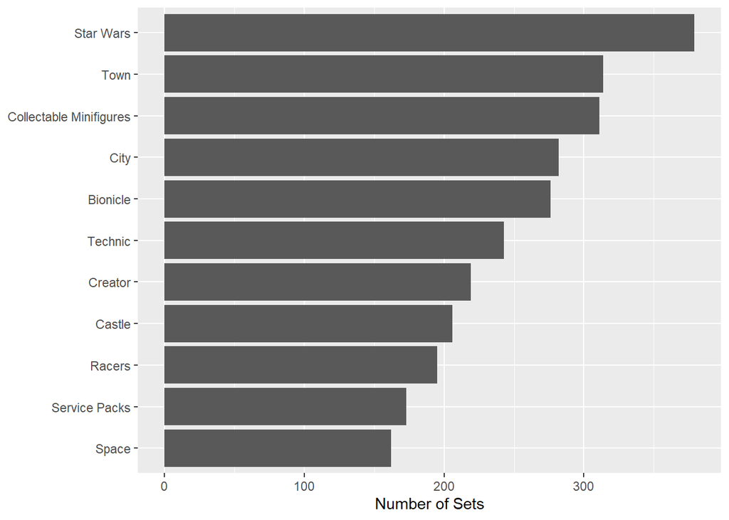

```r
#counts of the themes
df.1d <- legosets %>%
  #count data, automatically labeled 'n'
  count(Theme, sort = TRUE
        , name ="theme_count" #personalize name if wnat
        )  %>%
  #turning character chr into factor fct -- meaning a categorical variable
  mutate(Theme = fct_inorder(Theme, ordered = TRUE))



df.1d %>%
  filter(theme_count > 150, Theme != 'Duplo') %>% #only look at top ones
  ggplot(aes(x=fct_rev(Theme), y= theme_count)) +
    geom_col()+
    coord_flip()+
    labs(y="Number of Sets", x=NULL)
```

# Lab 02

## Overview

The goal of this lab is to begin the process of unlocking the power of `ggplot2` through constructing and experimenting with a few basic plots.

## Datasets

We’ll be using data from the `blue_jays.rda` dataset which is already in the `/data` subdirectory in our **data_vis_labs** project. Below is a description of the variables contained in the dataset.

- `BirdID` - ID tag for bird
- `KnownSex` - Sex coded as F or M
- `BillDepth` - Thickness of the bill measured at the nostril (in mm)
- `BillWidth` - Width of the bill (in mm)
- `BillLength` - Length of the bill (in mm)
- `Head` - Distance from tip of bill to back of head (in mm)
- `Mass` - Body mass (in grams)
- `Skull` - Distance from base of bill to back of skull (in mm)
- `Sex` - Sex coded as `0 = female` or `1 = male`

We’ll also be using a subset of the BRFSS (Behavioral Risk Factor Surveillance System) survey collected annually by the Centers for Disease Control and Prevention (CDC). The data can be found in the provided `cdc.txt` file — place this file in your `/data` subdirectory. The dataset contains 20,000 complete observations/records of 9 variables/fields, described below.

- `genhlth` - How would you rate your general health? (excellent, very good, good, fair, poor)
- `exerany` - Have you exercised in the past month? (`1 = yes`, `0 = no`)
- `hlthplan` - Do you have some form of health coverage? (`1 = yes`, `0 = no`)
- `smoke100` - Have you smoked at least 100 cigarettes in your life time? (`1 = yes`, `0 = no`)
- `height` - height in inches
- `weight` - weight in pounds
- `wtdesire` - weight desired in pounds
- `age` - in years
- `gender` - `m` for males and `f` for females

Notice we are setting a seed. This signifies we will be doing something that relies on a random process (e.g., random sampling). In order for our results to be reproducible we set the seed. This ensures that every time you run the code or someone else does, it will produce the exact same output. It is good coding etiquette to set the seed towards the top of your document/code.

```r
# Set the seed for reproducibility
set.seed(31412718)
```

```r
# Load package(s)
library(tidyverse)
```

## Exercises

Complete the following exercises.

### Exercise 1

Using `blue_jay` dataset, construct the following scatterplots of `Head` by `Mass`:

1. One with the `color` aesthetic set to Northwestern purple (`#4E2A84`), `shape` aesthetic set a solid/filled triangle, and `size` aesthetic set to 2.
2. One using `Sex` or `KnownSex` mapped to the `color` aesthetic. That is, determine which is more appropriate and explain why. Also set the `size` aesthetic to 2.

Consider the `color` aesthetic in the plots for (1) and (2). Explain why these two usages of the `color` aesthetic are meaningfully different.

```r
load(file = "data/blue_jays.rda")
head(blue_jays)
```

```
##       BirdID KnownSex BillDepth BillWidth BillLength  Head  Mass Skull Sex
## 1 0000-00000        M      8.26      9.21      25.92 56.58 73.30 30.66   1
## 2 1142-05901        M      8.54      8.76      24.99 56.36 75.10 31.38   1
## 3 1142-05905        M      8.39      8.78      26.07 57.32 70.25 31.25   1
## 4 1142-05907        F      7.78      9.30      23.48 53.77 65.50 30.29   0
## 5 1142-05909        M      8.71      9.84      25.47 57.32 74.90 31.85   1
## 6 1142-05911        F      7.28      9.30      22.25 52.25 63.90 30.00   0
```

#### Exercise 1.1

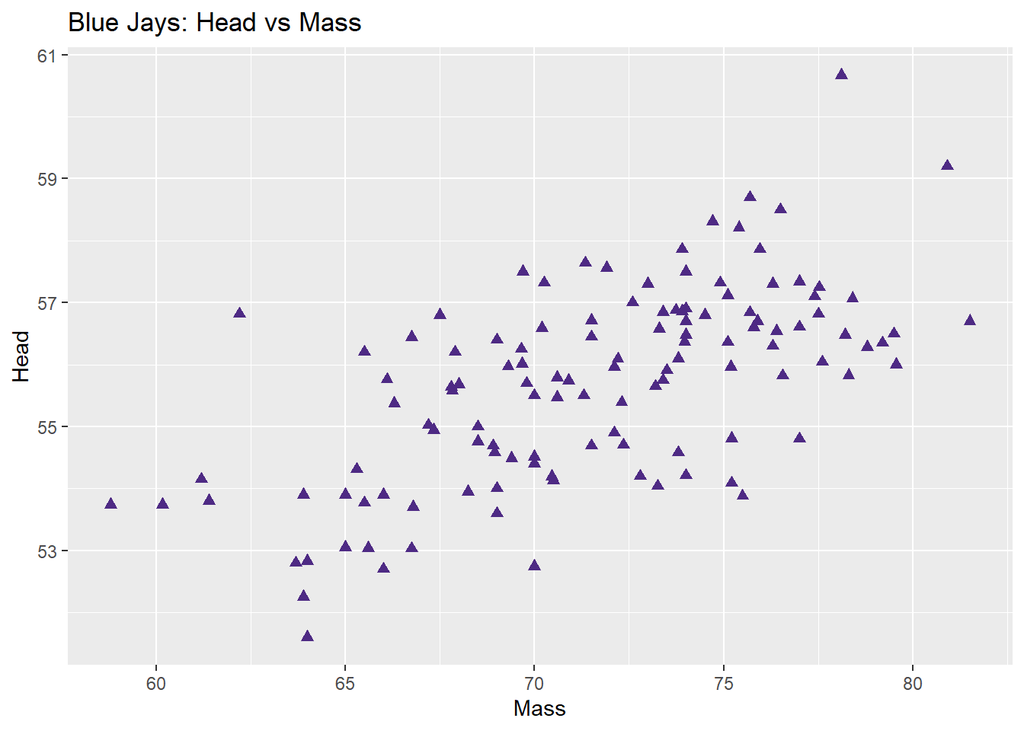

```r
ggplot(blue_jays, aes(Mass, Head))+
  geom_point(color="#4E2A84", shape=17, size=2)+
  ggtitle("Blue Jays: Head vs Mass")
```

#### Exercise 1.2

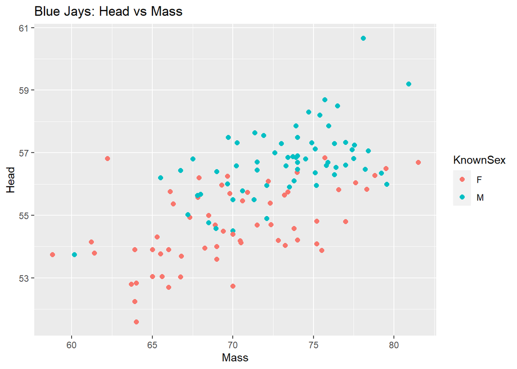

```r
ggplot(blue_jays, aes(Mass, Head, color=KnownSex))+
  geom_point(size=2)+
  ggtitle("Blue Jays: Head vs Mass")
```

The first plot uses colors for a purley subjective reason, a preferance for purple, but does not have any aesthetic effect on the data. The second plot uses the aesthetic color to section the data into two groups (Female and Male); this plot is using color as part of the mapping of the data to aesthetics.

### Exercise 2

Using a random subsample of size 100 from the `cdc` dataset (code provided below), construct a scatterplot of `weight` by `height`. Construct 5 more scatterplots of `weight` by `height` that make use of aesthetic attributes `color` and `shape` (maybe `size` too). You can define both aesthetics at the same time in each plot or one at a time. Just experiment. — Should be six total plots.

```r
# Read in the cdc dataset
cdc <- read_delim(file = "data/cdc.txt", delim = "|") %>%
  mutate(genhlth = factor(genhlth,
    levels = c("excellent", "very good", "good", "fair", "poor")
  ))

# Selecting a random subset of size 100
cdc_small <- cdc %>% sample_n(100)
```

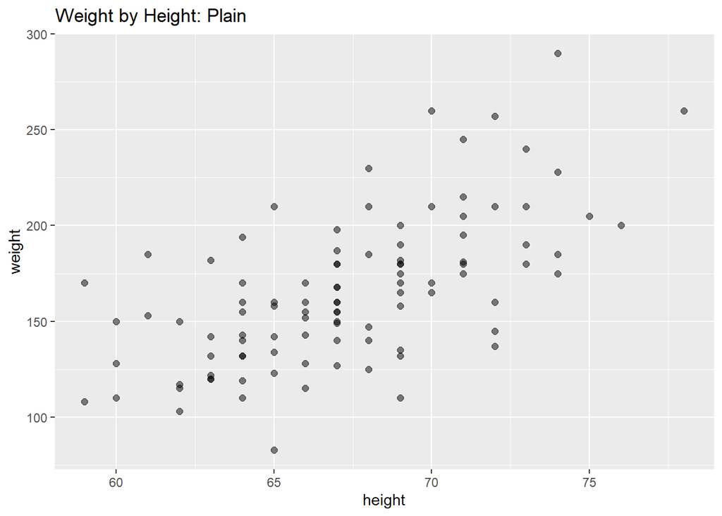

```r
#plot 1 plain
ggplot(cdc_small, aes(height, weight))+
  geom_point(size=2, alpha=0.5)+
  ggtitle("Weight by Height: Plain")
```

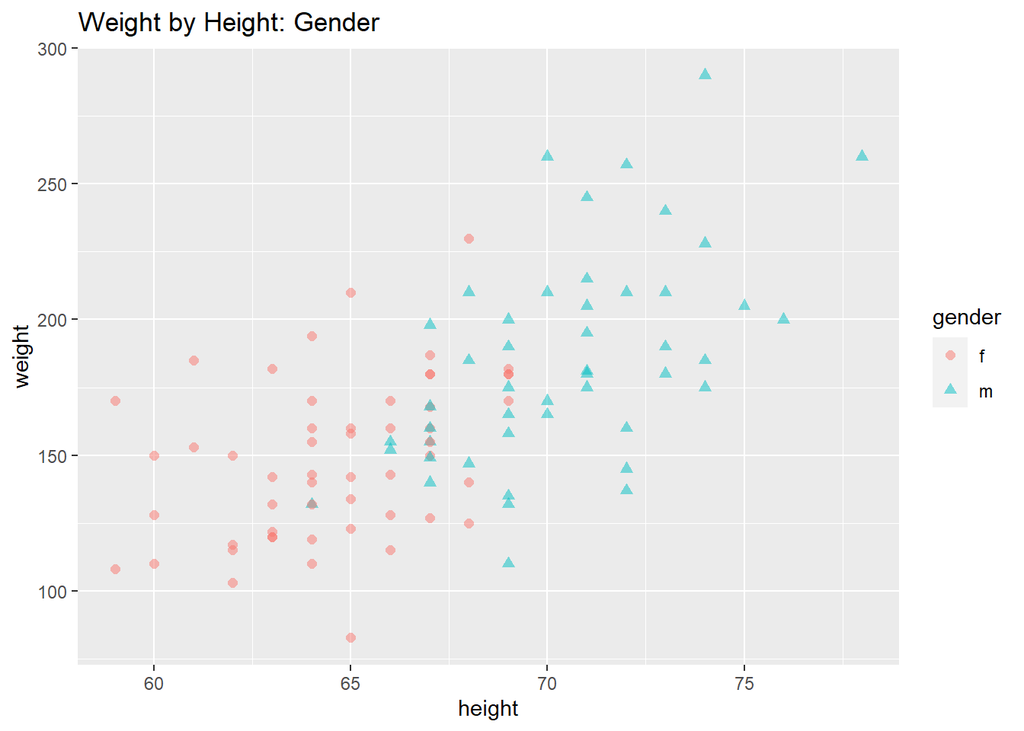

```r
#plot 2 gender
ggplot(cdc_small, aes(height, weight, shape=gender, color=gender))+
  geom_point(size=2, alpha=.5)+
  ggtitle("Weight by Height: Gender")
```

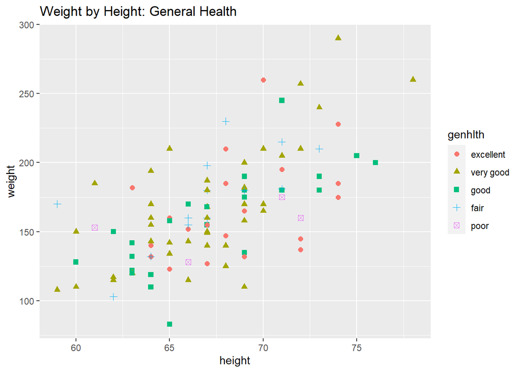

```r
#plot 3 general health
ggplot(cdc_small, aes(height, weight, color=genhlth, shape=genhlth))+
  geom_point(size=2)+
  ggtitle("Weight by Height: General Health")
```

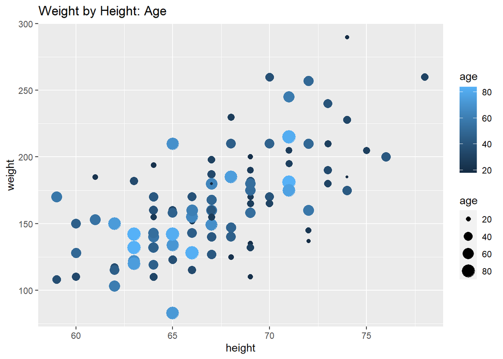

```r
#plot 4 age
ggplot(cdc_small, aes(height, weight, color=age, size=age))+
  geom_point()+
  ggtitle("Weight by Height: Age")
```

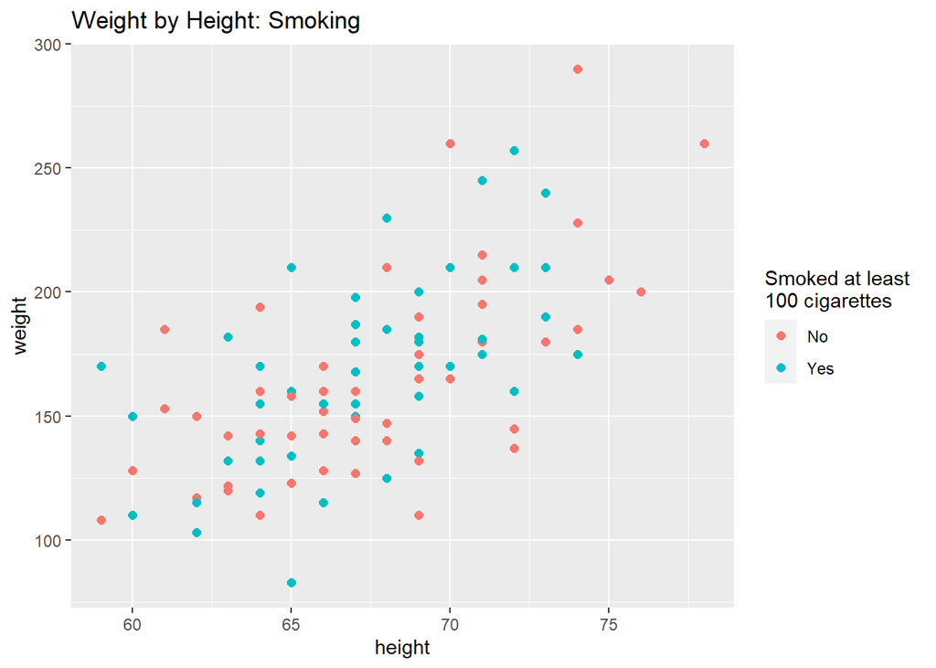

```r
#plot 5 smoking
ggplot(cdc_small, aes(height, weight, color=as.factor(smoke100)))+
  geom_point(size=2)+
  ggtitle("Weight by Height: Smoking")+
  scale_color_discrete(
     name="Smoked at least \n100 cigarettes"
    ,label=c("No", "Yes")
    )
```

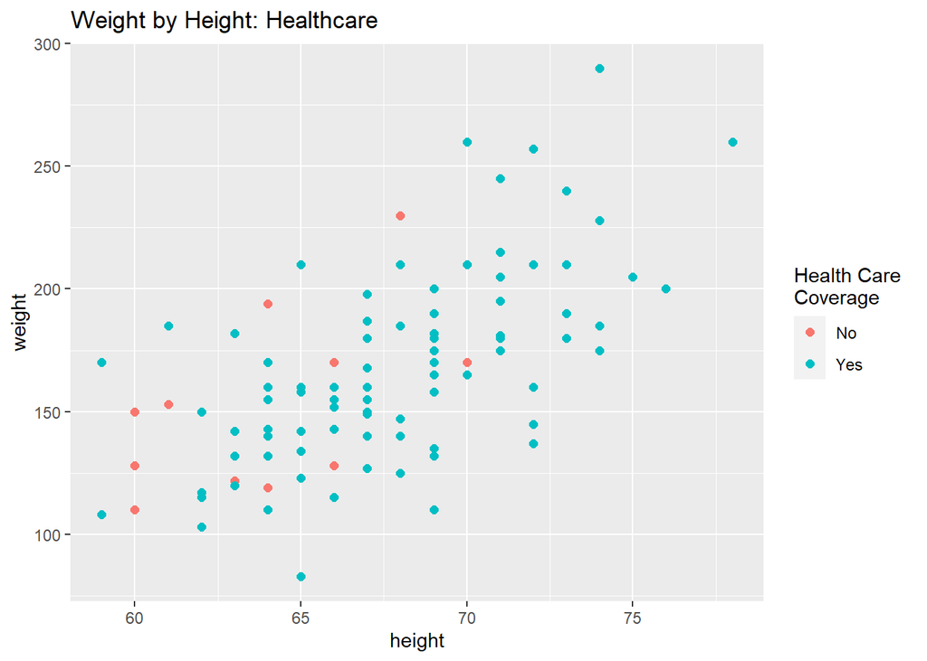

```r
#plot 5 healthcare coverage
ggplot(cdc_small, aes(height, weight, color=as.factor(hlthplan)))+
  geom_point(size=2)+
  ggtitle("Weight by Height: Healthcare")+
  scale_color_discrete(name="Health Care \nCoverage", label=c("No", "Yes"))
```

# Lab 03

```r
# Load package(s)
library(tidyverse)
library(lubridate) #for ymd() function
```

## Overview

The goal of this lab is to continue the process of unlocking the power of `ggplot2` through constructing and experimenting with a few basic plots.

## Datasets

We’ll be using data from the `BA_degrees.rda` and `dow_jones_industrial.rda` datasets which are already in the `/data` subdirectory in our **data_vis_labs** project. Below is a description of the variables contained in each dataset.

`BA_degrees.rda`

- `field` - field of study
- `year_str` - academic year (e.g. 1970-71)
- `year` - closing year of academic year
- `count` - number of degrees conferred within a field for the year
- `perc` - field’s percentage of degrees conferred for the year

```r
load(file="data/BA_degrees.rda")
```

`dow_jones_industrial.rda`

- `date` - date
- `open` - Dow Jones Industrial Average at open
- `high` - Day’s high for the Dow Jones Industrial Average
- `low` - Day’s low for the Dow Jones Industrial Average
- `close` - Dow Jones Industrial Average at close
- `volume` - number of trades for the day

```r
load(file="data/dow_jones_industrial.rda")
```

We’ll also be using a subset of the BRFSS (Behavioral Risk Factor Surveillance System) survey collected annually by the Centers for Disease Control and Prevention (CDC). The data can be found in the provided `cdc.txt` file — place this file in your `/data` subdirectory. The dataset contains 20,000 complete observations/records of 9 variables/fields, described below.

- `genhlth` - How would you rate your general health? (excellent, very good, good, fair, poor)
- `exerany` - Have you exercised in the past month? (`1 = yes`, `0 = no`)
- `hlthplan` - Do you have some form of health coverage? (`1 = yes`, `0 = no`)
- `smoke100` - Have you smoked at least 100 cigarettes in your life time? (`1 = yes`, `0 = no`)
- `height` - height in inches
- `weight` - weight in pounds
- `wtdesire` - weight desired in pounds
- `age` - in years
- `gender` - `m` for males and `f` for females

```r
cdc <- read_delim(file = "data/cdc.txt", delim = "|") %>%
  mutate(genhlth = factor(genhlth,
    levels = c("excellent", "very good", "good", "fair", "poor")
  ))
```

## Exercises

### Exercise 1

The following exercises use the `BA_degrees` data set.

```r
# Wrangling for plotting
ba_dat <- BA_degrees %>%
  # mean % per field
  group_by(field) %>%
  mutate(mean_perc = mean(perc)) %>%
  # Only fields with mean >= 5%
  filter(mean_perc >= 0.05) %>%
  # Organizing for plotting
  arrange(desc(mean_perc), year) %>%
  ungroup() %>%
  mutate(field = fct_inorder(field))

#take a look at the data to see variable names and types
head(ba_dat)
```

```
## # A tibble: 6 x 6
##   field    year_str  year  count  perc mean_perc
##   <fct>    <chr>    <dbl>  <dbl> <dbl>     <dbl>
## 1 Business 1970-71   1971 115396 0.137     0.204
## 2 Business 1975-76   1976 143171 0.155     0.204
## 3 Business 1980-81   1981 200521 0.214     0.204
## 4 Business 1985-86   1986 236700 0.240     0.204
## 5 Business 1990-91   1991 249165 0.228     0.204
## 6 Business 1995-96   1996 226623 0.195     0.204
```

#### Plot 1

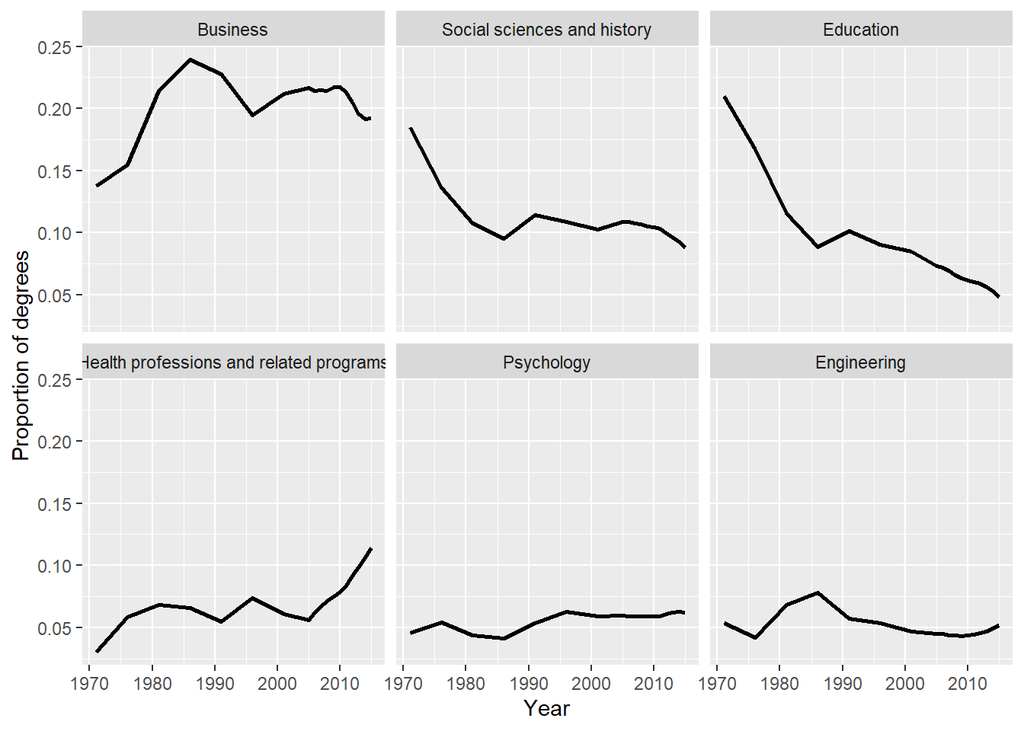

```r
#percent of degrees conferred by year
ggplot(ba_dat, aes(year, perc)) +
  geom_line(size=1) +
  #make chart for each field
  facet_wrap(~field) +
  xlab("Year") +
  ylab("Proportion of degrees")
```

#### Plot 2

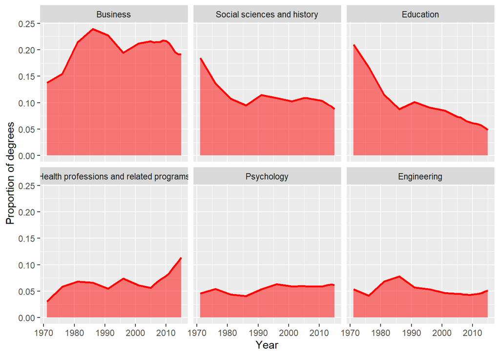

```r
#percent of degrees conferred by year
ggplot(ba_dat, aes(year, perc)) +
   #colored area may make comparison between field easier
  geom_area(alpha=0.5, fill="red") +
  #line on areaa (may want a different color )
  geom_line(color="red", size=1) +
  #make chart for each field
  facet_wrap(~field) +
  xlab("Year") +
  ylab("Proportion of degrees")
```

#### Plot 3

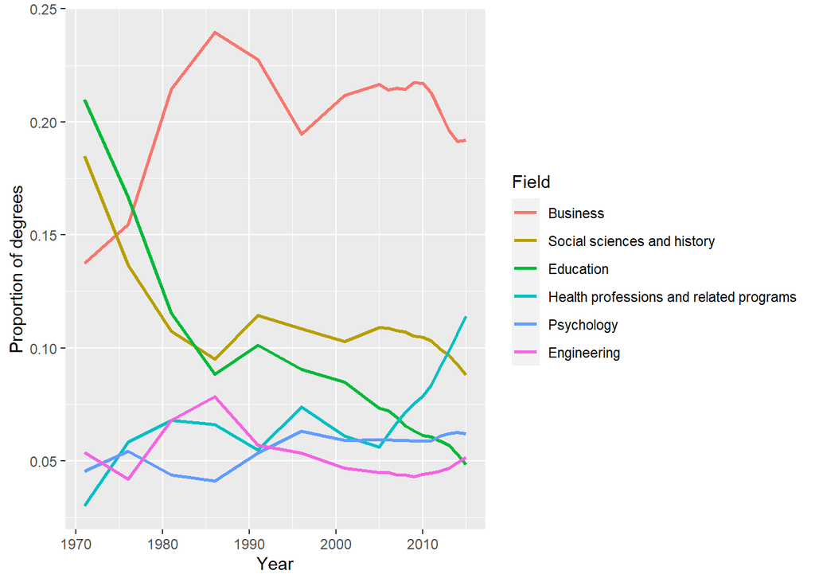

```r
#percent of degrees conferred by year
ggplot(ba_dat
       , aes(
           year
         , perc
         #sample plot, differnet line color by field
         , color=field
         )
       ) +
  geom_line(size=1) +
  xlab("Year") +
  ylab("Proportion of degrees") +
  #change title on legend
  labs(color="Field")
```

### Exercise 2

The following exercises use the `dow_jones-industrial` data set.

```r
# Restrict data to useful range
djia_date_range <- dow_jones_industrial %>%
  filter(date >= ymd("2008/12/31") & date <= ymd("2010/01/10"))

#take a look at the data to see variable names and types
head(djia_date_range)
```

```
## # A tibble: 6 x 6
##   date        open  high   low close    volume
##   <date>     <dbl> <dbl> <dbl> <dbl>     <int>
## 1 2008-12-31 8666. 8843. 8665. 8776. 226760000
## 2 2009-01-02 8772. 9065. 8761. 9035. 213700000
## 3 2009-01-05 9027. 9034. 8892. 8953. 233760000
## 4 2009-01-06 8955. 9088. 8941. 9015. 215410000
## 5 2009-01-07 8997. 8997. 8720. 8770. 266710000
## 6 2009-01-08 8770. 8770. 8651. 8742. 226620000
```

#### Plot 1

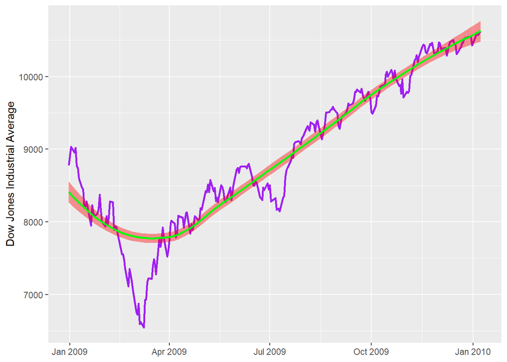

```r
#closing price of DJIA by date
ggplot(djia_date_range, aes(date, close)) +
  geom_line(size = 1, color="purple") +
  geom_smooth(
      method = "loess"
    , formula = y ~ x
    #line color
    , color = "green"
    #se shading color
    , fill = "red"
    ) +
  xlab(NULL) +
  ylab("Dow Jones Industrial Average")
```

#### Plot 2

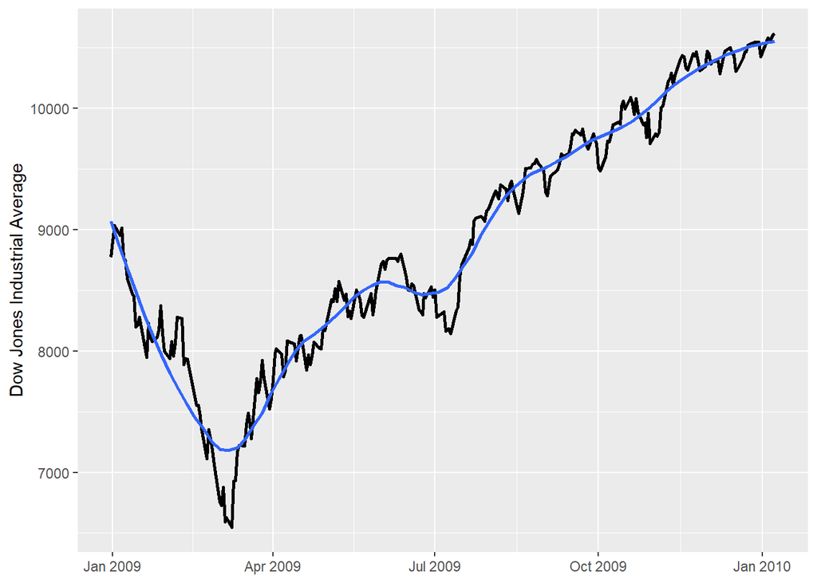

```r
#closing price of DJIA by date
ggplot(djia_date_range, aes(date, close)) +
  geom_line(size=1) +
  geom_smooth(
      method="loess"
    , formula= y ~ x
    #wiggliness for loess curve
    , span=0.3
    #don't show se
    , se=FALSE
    ) +
  xlab(NULL) +
  ylab("Dow Jones Industrial Average")
```

#### Plot 3

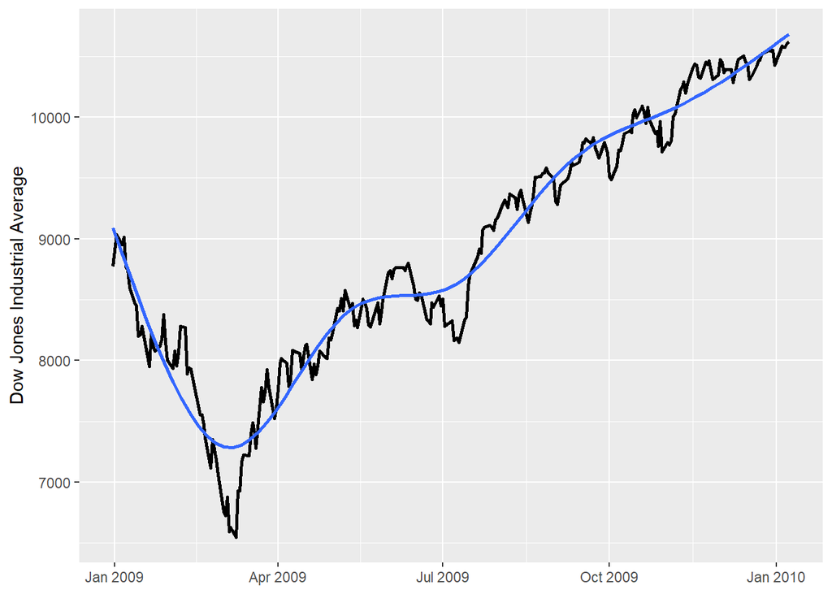

```r
ggplot(djia_date_range, aes(date, close)) +
  geom_line(size=1) +
  geom_smooth(
      method="lm"
      #splines makes the line more curvy and less 'chopped up'
      #splines use piecewise polynomials
      #lowess is 'local regression'
    , formula= y ~ splines::ns(x, 6)
    , span=0.3
    , se = FALSE
    ) +
  xlab(NULL) +
  ylab("Dow Jones Industrial Average")
```

### Exercise 3

The following exercises use the `cdc` dataset.

```r
#take a look at the data to see variable names and types
head(cdc)
```

```
## # A tibble: 6 x 9
##   genhlth   exerany hlthplan smoke100 height weight wtdesire   age gender
##   <fct>       <dbl>    <dbl>    <dbl>  <dbl>  <dbl>    <dbl> <dbl> <chr>
## 1 good            0        1        0     70    175      175    77 m
## 2 good            0        1        1     64    125      115    33 f
## 3 good            1        1        1     60    105      105    49 f
## 4 good            1        1        0     66    132      124    42 f
## 5 very good       0        1        0     61    150      130    55 f
## 6 very good       1        1        0     64    114      114    55 f
```

#### Plot 1

**Using `cdc` and `geom_bar()**

```r
ggplot(cdc, aes(genhlth)) +
  #count genhlth
  geom_bar()
```

[output not shown]

**Using `genhlth_count` and `geom_bar(stat="identity")`**

```r
#count genhlth and put into new data set
genhlth_count <- cdc %>%
  count(genhlth)

#take a look at the data to see variable names and types
genhlth_count
```

```
## # A tibble: 5 x 2
##   genhlth       n
##   <fct>     <int>
## 1 excellent  4657
## 2 very good  6972
## 3 good       5675
## 4 fair       2019
## 5 poor        677
```

```r
ggplot(genhlth_count, aes(genhlth, n)) +
  #use stat='identity' to plot actual values; rather than counting values
  geom_bar(stat="identity") +
  ylab("count")
```

[output not shown]

**Using `genhlth_count` and `geom_col()`**

```r
ggplot(genhlth_count, aes(genhlth, n)) +
  #geom_col will authomatically plot values
  # where as geom_bar requires stat="identity" to do so
  geom_col() +
  ylab("count")
```

[output not shown]

#### Plot 2

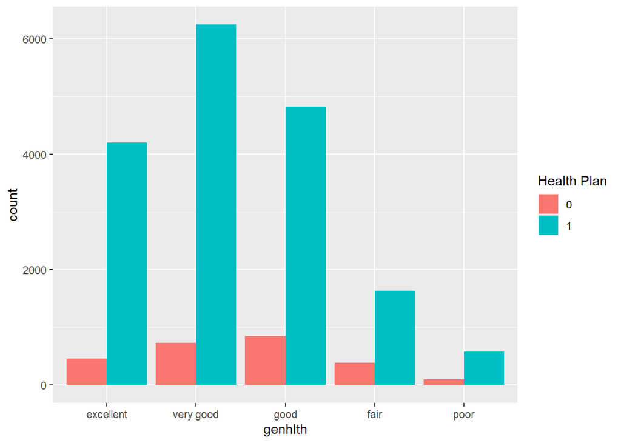

```r
ggplot(cdc, aes(genhlth, fill=as.factor(hlthplan))) +
  geom_bar(position="dodge") +
  #change title on legend
  labs(fill="Health Plan")
```

#### Plot 3

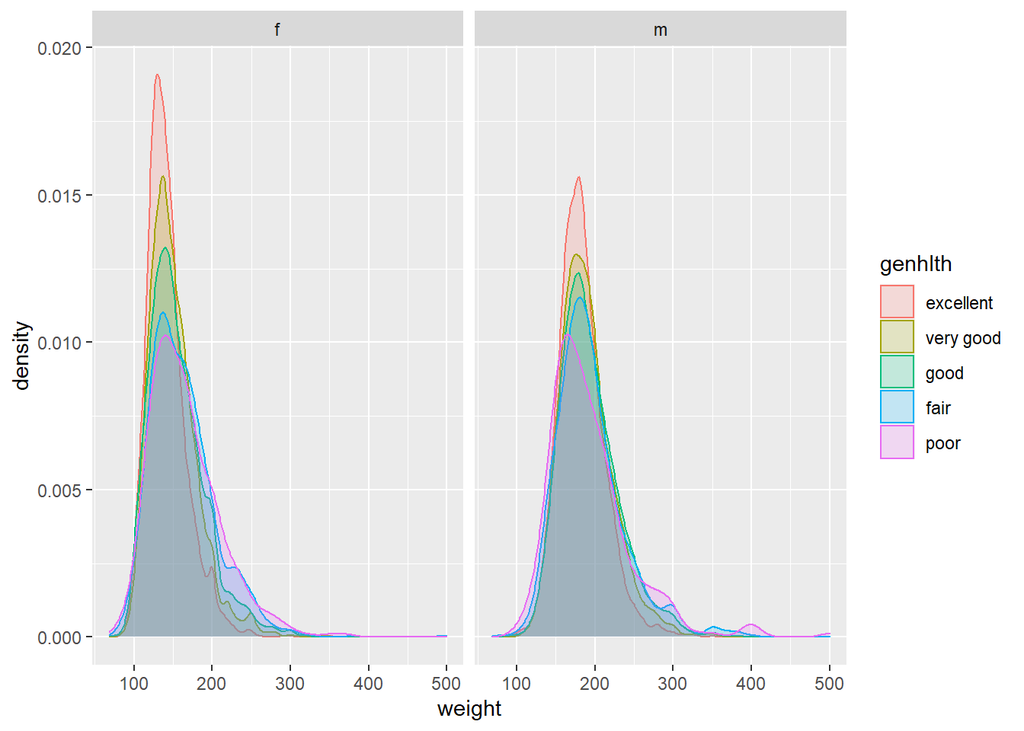

```r
ggplot(cdc
       , aes(
         #variable used to  calculate density
           weight
          #color of area
         , fill = genhlth
         #color of line
         , color = genhlth
         )
       ) +
  geom_density(alpha = 0.2) +
  # create plots for each gender
  facet_wrap(~gender)
```

#### Plot 4

The weight variable should have a lower limit of 50 and an upper limit of 300.

**Fix x-axis limits**

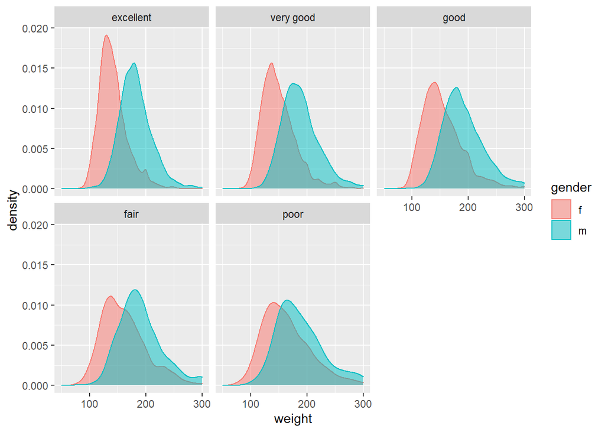

```r
ggplot(cdc, aes(weight, fill = gender, color = gender)) +
  geom_density(alpha = 0.5) +
  facet_wrap(~genhlth, scales = "fixed") +
  xlim(50, 300)
```

**Filter cdc df to weight values [50, 300]**

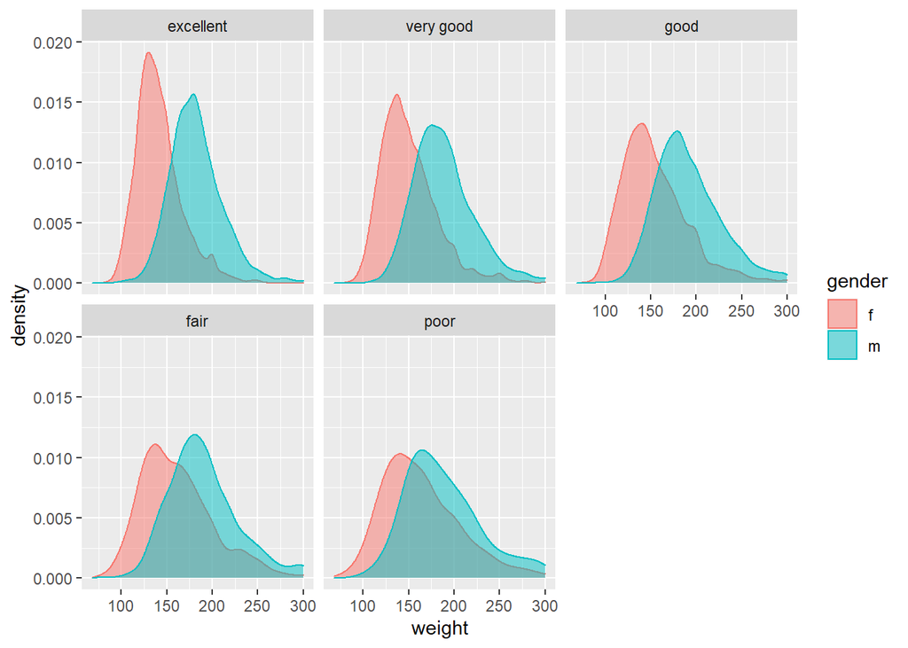

```r
cdc %>%
  #filter data to only include values within the limts
  filter(weight >= 50, weight <= 300) %>%
#pip directly into ggplot
ggplot(aes(weight, fill = gender, color=gender)) +
  geom_density(alpha=0.5) +
  facet_wrap(~genhlth, scales = "fixed")
```

#### Plot 5

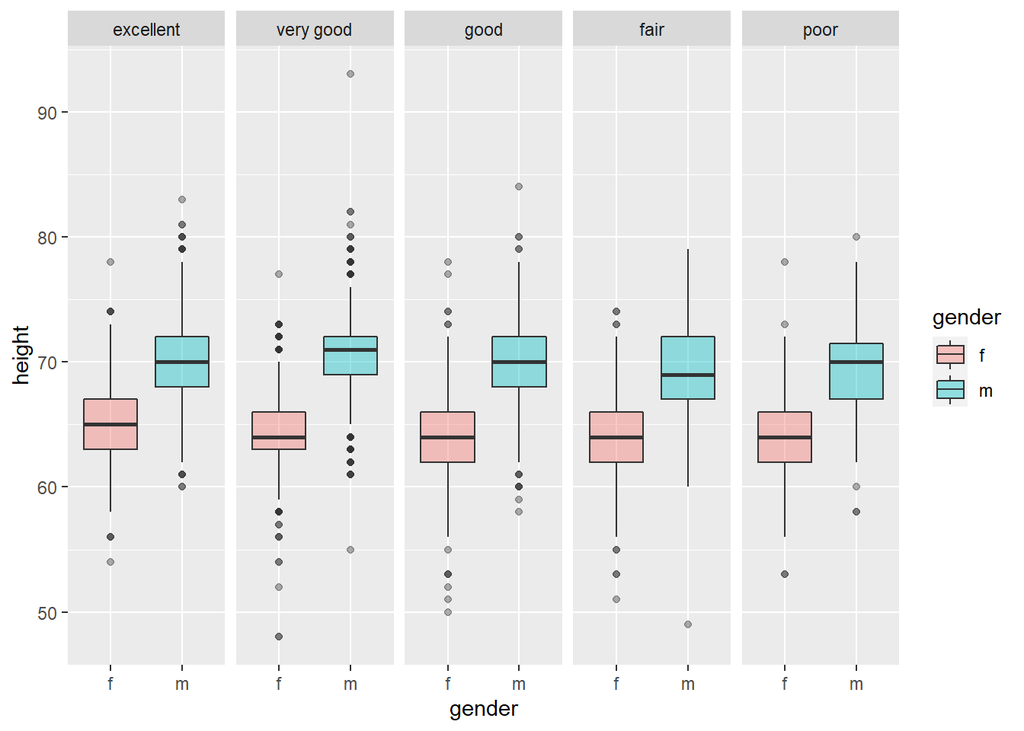

```r
ggplot(cdc, aes(height, gender,  fill = gender)) +
  geom_boxplot(alpha = 0.4) +
  facet_wrap(~genhlth, nrow = 1) +
  coord_flip()
```

#### Plot 6

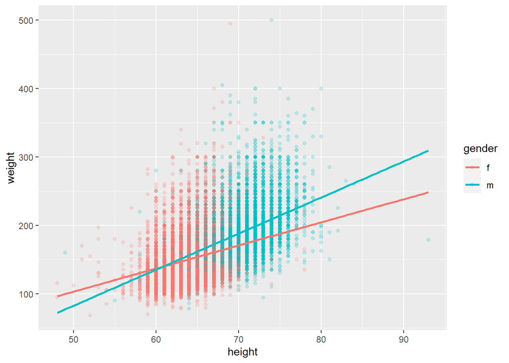

```r
ggplot(cdc,
       aes(
           height
         , weight
         #put color here, inherited to geom_point and geom_smooth as well
         , color = gender
         )
       ) +
  geom_point(alpha = 0.2) +
  geom_smooth(
      method = "lm"
    , formula = y~x
    , se = FALSE
    #extend line to cover whole plot
    , fullrange = TRUE
    )
```

# Lab 04

## Overview

The goal of this lab is to continue the process of unlocking the power of `ggplot2` through constructing and experimenting with a few basic plots.

**Load Packages:** `tidyverse`, `gridExtra`, `ggrepel`

```r
# Load package(s)
suppressPackageStartupMessages(library(tidyverse))
suppressPackageStartupMessages(library(gridExtra))
suppressPackageStartupMessages(library(ggrepel))

knitr::opts_chunk$set(dpi = 300)
```

## Datasets

We’ll be using data from the `blue_jays.rda`, `tech_stocks.rda`, `corruption.rda`, and `cdc.txt` datasets which are already in the `/data` subdirectory in our **data_vis_labs** project.

```r
# Load datasets
load(file = "data/blue_jays.rda")
load(file = "data/tech_stocks.rda")
load(file = "data/corruption.rda")

# Read in the cdc dataset
cdc <- read_delim(
  file = "data/cdc.txt"
  , delim = "|"
  ) %>%
  mutate(genhlth = factor(genhlth,
    levels = c("excellent", "very good", "good", "fair", "poor")
  ))
```

## Exercises

### Exercise 1

The following plot uses the `blue_jays.rda` dataset.

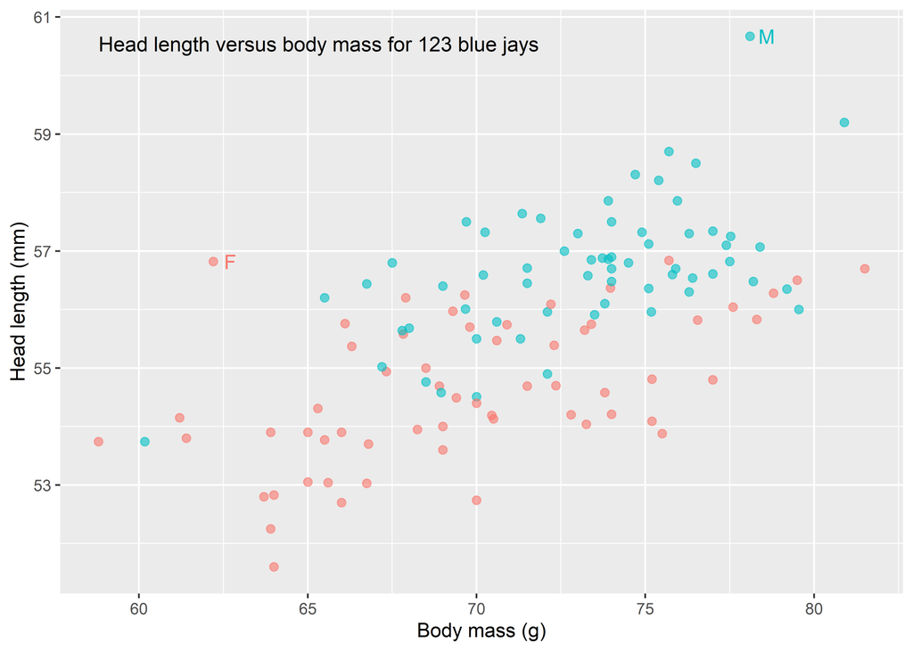

```r
#create caption that automatically grabs number of blue jays
caption <- paste("Head length versus body mass for", nrow(blue_jays), "blue jays")

#add string wrap
#will break the caption into multiple lines if longer than 40 characters
# '\n' is the line break code
caption_print <- paste(strwrap(caption, 40), collapse ="\n")

#create data set for top head size for each sex
topHead <- blue_jays %>%
  #arrange largest to smallest
  arrange(desc(Head)) %>%
  # group by sex
  group_by(KnownSex) %>%
  #take the top 2 head sizes  for each group
  top_n(n = 2, wt = Head)

#'M' label will be put on the top male head size
#'F' label will be put on the 2nd top female head size
Labels <- topHead[c(1,4),]

#ANOTHER OPTIONS: lable dataframe
#search by BirdID
Labels_anotheroption <- blue_jays  %>%
  #select specific bird where you want the labels
  filter(BirdID %in% c("1142-05914", "702-90567"))

#get range for x and y variables
xrng <- range(blue_jays$Mass)
yrng <- range(blue_jays$Head)

#head length by body mass
ggplot(blue_jays, aes(Mass, Head, color = KnownSex)) +
  geom_point(alpha = 0.6, size = 2) +
  annotate(
     "text"
    #put text in the top left corner of plot
    , x = xrng[1], y = yrng[2]
    #label is the caption already create
    , label = caption
    #left justify
    , hjust = 0
    # bottom justify
    , vjust = 1
    #size the font
    , size = 4
    ) +
  xlab("Body mass (g)") +
  ylab("Head length (mm)") +
  #remove all legends; to remove just one legend put show.legend = FALSE into geom
  theme(legend.position = "none") +
  # add labels
  geom_text(
    #use labels data set
      data = Labels
    , aes(label = KnownSex)
    #nudget labels to the right
    , nudge_x = 0.5
    )
```

### Exercise 2

The following plots use the `tech_stocks` dataset.

#### Plot 1

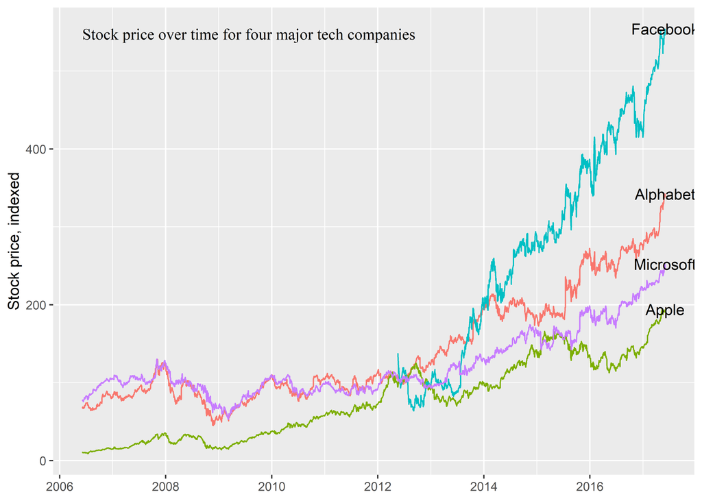

```r
#create caption
caption <- paste("Stock price over time for four major tech companies")

#add string wrap
#will break the caption into multiple lines if longer than 40 characters
# '\n' is the line break code
caption_print <- paste(strwrap(caption, 40), collapse = "\n")

#create labels df with most recent stock values
Labels <- tech_stocks %>%
  #order by date
  arrange(desc(date)) %>%
  # return distinct company
  distinct(company
           #keep all variables not just company
           , .keep_all = TRUE
           )

#get range for x and y variables
xrng <- range(tech_stocks$date)
yrng <- range(tech_stocks$price_indexed)

#stock price by date
ggplot(tech_stocks, aes(date, price_indexed)) +
  #put color in geom_line so labels are not colored
  geom_line(aes(color = company)) +
  # remove all legends
  theme(legend.position  =  "none") +
  #remove x label
  xlab(NULL) +
  ylab("Stock price, indexed") +
  annotate(
    "text"
    #put text in the top left corner of plot
    , x = xrng[1], y = yrng[2]
     #label is the caption already create
    , label = caption
    #left justify
    , hjust = 0
    # bottom justify
    , vjust = 1
    #use serif font
    , family = "serif"
    #size the font
    , size = 4
    ) +
  #add company labels to the most recent stock price
  geom_text(data = Labels, aes(label = company))
```

#### Plot 2

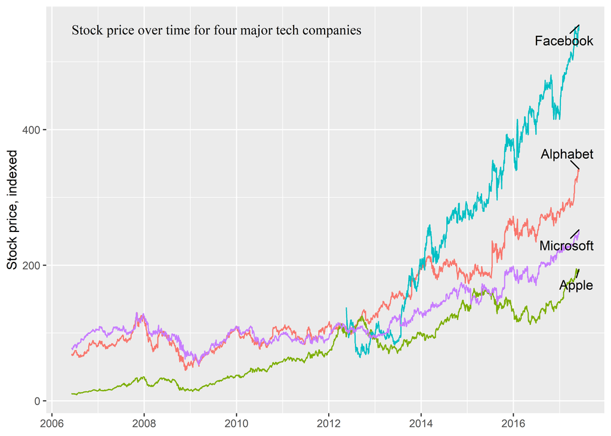

```r
#stock price by date
ggplot(tech_stocks, aes(date, price_indexed)) +
  #put color in geom_line so labels are not colored
  geom_line(aes(color = company)) +
  # remove all legends
  theme(legend.position  =  "none") +
  #remove x label
  xlab(NULL) +
  ylab("Stock price, indexed") +
  annotate(
    "text"
    #put text in the top left corner of plot
    , x = xrng[1], y = yrng[2]
     #label is the caption already create
    , label = caption
    #left justify
    , hjust = 0
    # bottom justify
    , vjust = 1
    #use serif font
    , family = "serif"
    #size the font
    , size = 4
    ) +
  #add company labels to the most recent stock price
  geom_text_repel(
      data = Labels
    , aes(label = company)
    #padding around label
    , box.padding = 0.6
    , min.segment.length = 0
    #right align text (so doesn't go off the plot)
    , hjust = 1
    #set seed for repel iterations
    , seed = 9876
    )
```

### Exercise 3

The following plot uses the `corruption.rda` dataset.

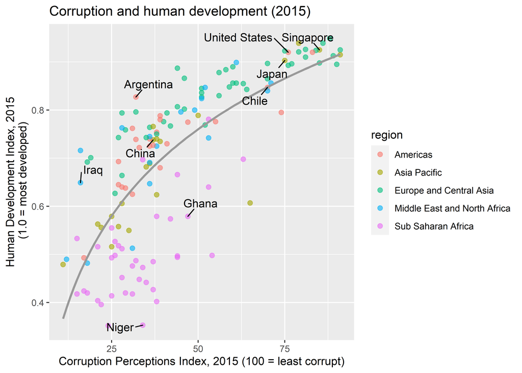

```r
#look at 2015 data
corruption_2015 <- corruption %>%
  #remove countries that don't have cpi or hdi values
  drop_na(cpi, hdi) %>%
  #only look at 2015 data
  filter(year == 2015)

#the contries we want to label
CountriesToLabel <- c(
    "Niger"
  , "Iraq"
  , "China"
  , "Ghana"
  , "Argentina"
  , "Chile"
  , "Japan"
  , "United States"
  , "Singapore"
  )

#create labels data frame
Labels <- corruption_2015 %>%
  #only select specific countries already specified
  filter( country %in% CountriesToLabel)

#hdi by cpi
ggplot(corruption_2015, aes(cpi, hdi)) +
  #put color in geom_line so labels are not colored, color by geom
  geom_point(aes(color = region), alpha = 0.6, size = 2) +
    geom_smooth(
        method = "lm"
      # use log(x) when modeling
      , formula =  y~log(x)
      # specify grey color for line
      , color = "grey60"
      # remove standard error bars
      , se = FALSE
      ) +
  xlab("Corruption Perceptions Index, 2015 (100 = least corrupt)") +
  #add y label; '\n' creates line break
  ylab("Human Development Index, 2015\n (1.0 = most developed)") +
  #add title
  ggtitle("Corruption and human development (2015)")+
  #add labels to specific countries
  geom_text_repel(
      data = Labels
    , aes(label = country)
    #set seed for repel iterations
    , seed  =  9876
    , box.padding  =  0.6
    , min.segment.length = 0
    )
```

### Exercise 4

The next plot uses the `cdc` dataset.

Using Bilbo Baggins’ responses below to the CDC BRSFF questions, add Bilbo’s data point as a transparent (0.5) solid red circle of size 4 to a scatterplot of `weight` by `height` with transparent (0.1) solid blue circles of size 2 as the plotting characters. In addition, label the point with his name in red. Left justify and rotate the label so it reads vertically from bottom to top — shift it up by 10 pounds too. Plot should use appropriately formatted axis labels. Remember that the default shape is a solid circle.

- `genhlth` - How would you rate your general health? **fair**
- `exerany` - Have you exercised in the past month? **1=yes**
- `hlthplan` - Do you have some form of health coverage? **0=no**
- `smoke100` - Have you smoked at least 100 cigarettes in your life time? **1=yes**
- `height` - height in inches: **46**
- `weight` - weight in pounds: **120**
- `wtdesire` - weight desired in pounds: **120**
- `age` - in years: **45**
- `gender` - m for males and f for females: **m**

*Hint:* Create a new dataset (maybe call it `bilbo` or `bilbo_baggins`) using either `data.frame()` (base R - example in book) or `tibble()` (tidyverse - see help documentation for the function). Make sure to use variable names that exactly match `cdc`’s variable names

[figure not shown]

```r
bilbo <- tibble(
  genhlth = "fair",
  exerancy = 1,
  hlthplan = 0,
  smoke100 = 1,
  height = 46,
  weight = 120,
  wtdesire = 120,
  age = 45,
  gender = "m"
)

ggplot(cdc, aes(height, weight)) +
  geom_point(alpha = 0.1, color = "blue", size = 2) +
  ggtitle("Bilbo Baggins is on the small side") +
  labs(
      x = "Height (inches)"
    , y = "Weight (pounds)"
    , subtitle = "CDC Data: Weight by Height"
  ) +
  #add Bilbo Baggins special red point onto graph
  geom_point(data = bilbo, color = "red", size = 4, alpha = 0.5) +
  #add sing label
  geom_text(
      data = bilbo
    , aes(label = "Bilbo Baggins")
    , color = "red"
    #left justify label
    , hjust = 0
    #rotate label
    , angle = 90
    #nudge label up 10 pounds
    , nudge_y = 10
    )
```